# REPORT of PRORAD STUDY

## Welcome to ProRaD Study!

ProRaD: **Pro**spective longitudinal study to investigate the **R**emission phase in patients with **A**topic **D**ermatitis (AD) and other allergy-associated diseases such as asthma, food allergies and allergic rhinitis (hay fever).

**Study Objective**:

-Better **understanding of the mechanisms influencing** the **course of AD** and allergic diseases.

-Better **characterization of the broad clinical spectrum**.

-Development of clinically relevant and validated **biomarkers**.

-Development of new approaches for the **prevention and treatment of atopic dermatitis and associated diseases**.

**Practical procedure of the study** :

Centers in *Germany* & *Switzerland* : 1 study visit/year over 5 years to monitor individual disease progression, with a duration of 2 hours per visit.

**SECUTRIAL** : Patient questionnaires, physical examination

**OPENSPECIMEN** : Collection of blood/ skin swabs/ if necessary skin biopsy

## PRORAD

### SECUTRIAL (2025-02-10)

> **2713** ID in PRORAD secutrial

> **5205** visit in PRORAD secutrial

Total number of ID per center in PRORAD

| augsburg | bonn | davos | zürich |
| --- | --- | --- | --- |
| 417 | 1493 | 543 | 260 |

### OPENSPECIMEN (2025-02-10)

> **2738** ID in PRORAD openspecimen

> **90337** samples in PRORAD openspecimen

Total number of samples in PRORAD openspecimen

| Specimen_Type | Total |
| --- | --- |
| skin_swab | 14926 |
| skin_biopsy | 978 |
| whole_blood | 8732 |
| edta_aliquot | 15727 |
| pbmc_aliquot | 23333 |
| serum_aliquot | 26641 |

## PRORAD SECUTRIAL

### SECUTRIAL TIMEPOINTS

> First look at the number of inclusion per center throught the year

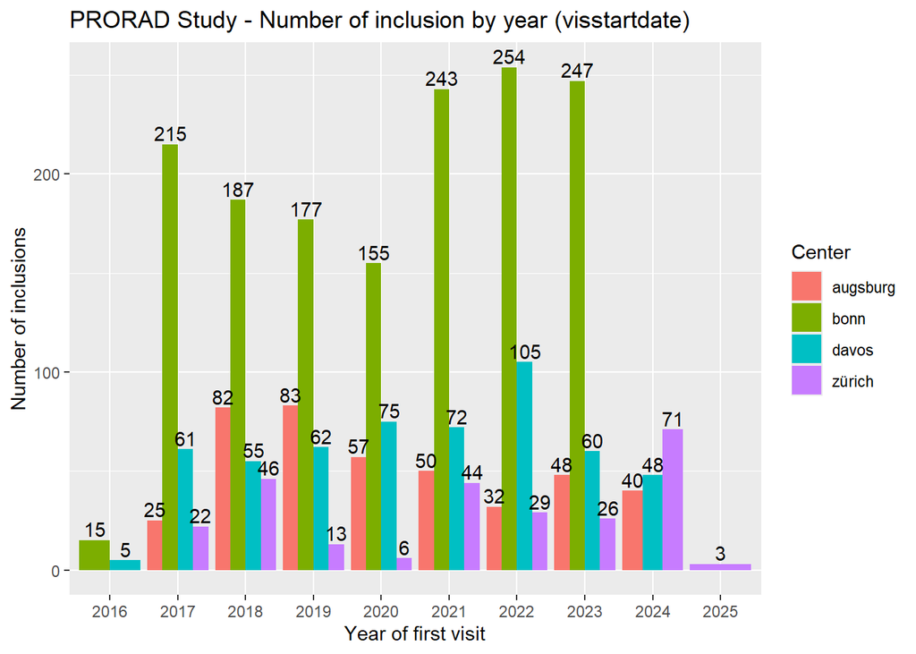

> Differences can be explain with missing values or error for some year ( 86 patients )

### SECUTRIAL DETAILS

#### AD

> First look at the AD

> The rest of T0 inclusions are classified as non-AD ( **740**) or missing/NA ( **2**)

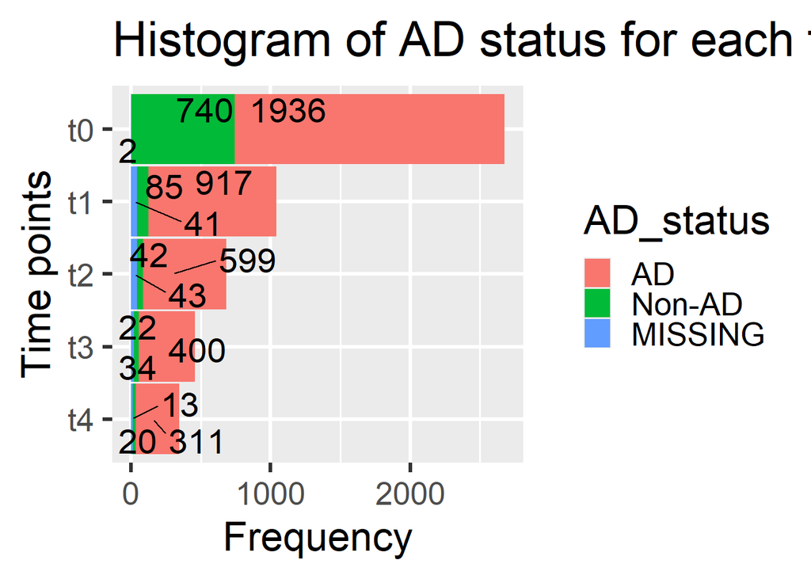

#### AD SCORES

> - The different SCORES available in PRORAD for the AD patient:
>   - SCORAD (SCORing Atopic Dermatitis)
>   - EASI (Eczema Area and Severity Index)
>   - DLQI (Dermatology Life Quality Index)
>   - POEM (Patient Oriented Eczema Measure)
>   - Recap (Recap of atopic eczema)

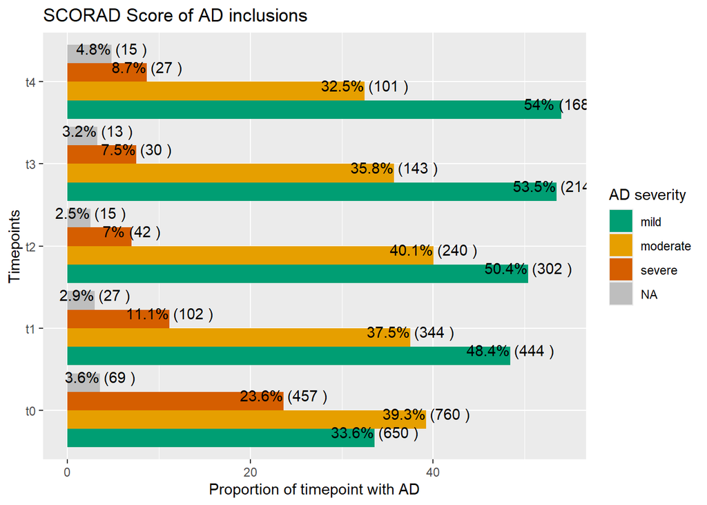

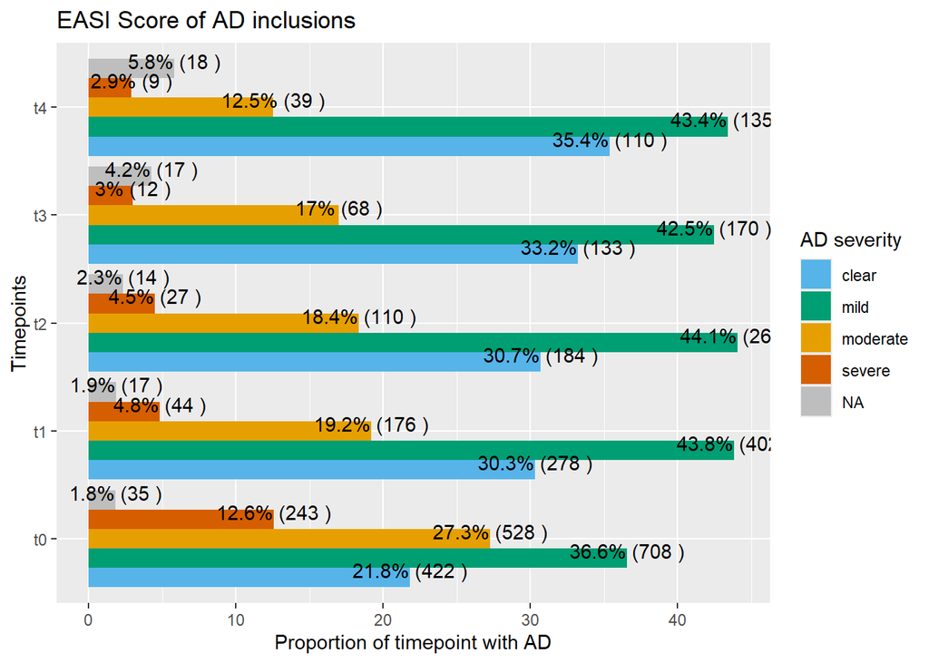

#### AGE PRORAD STUDY

> Look at the age proportion of Adult with AD at T0 and at AD onset. (out of **1936** inclusions)

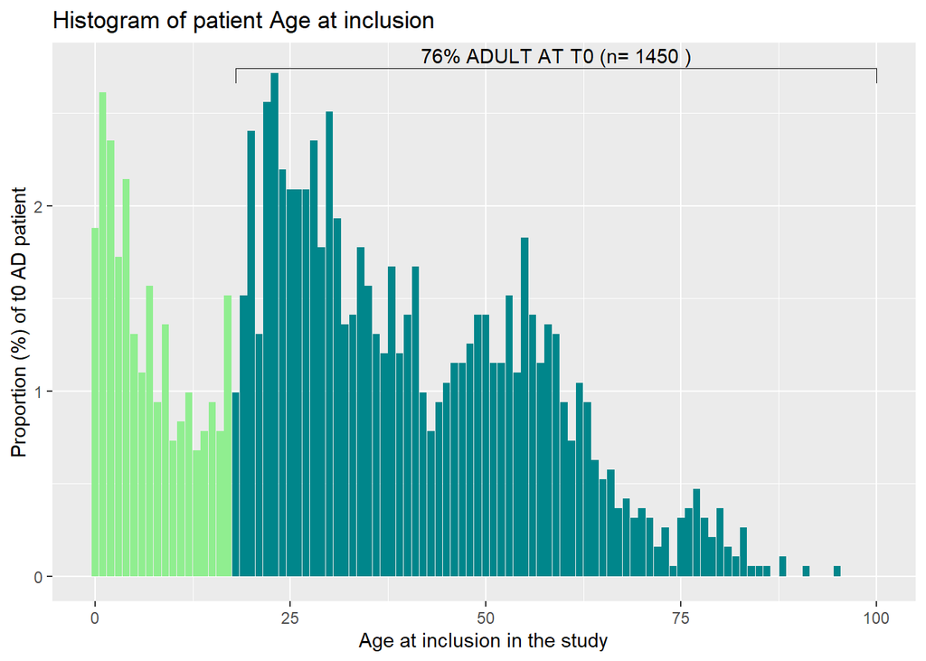

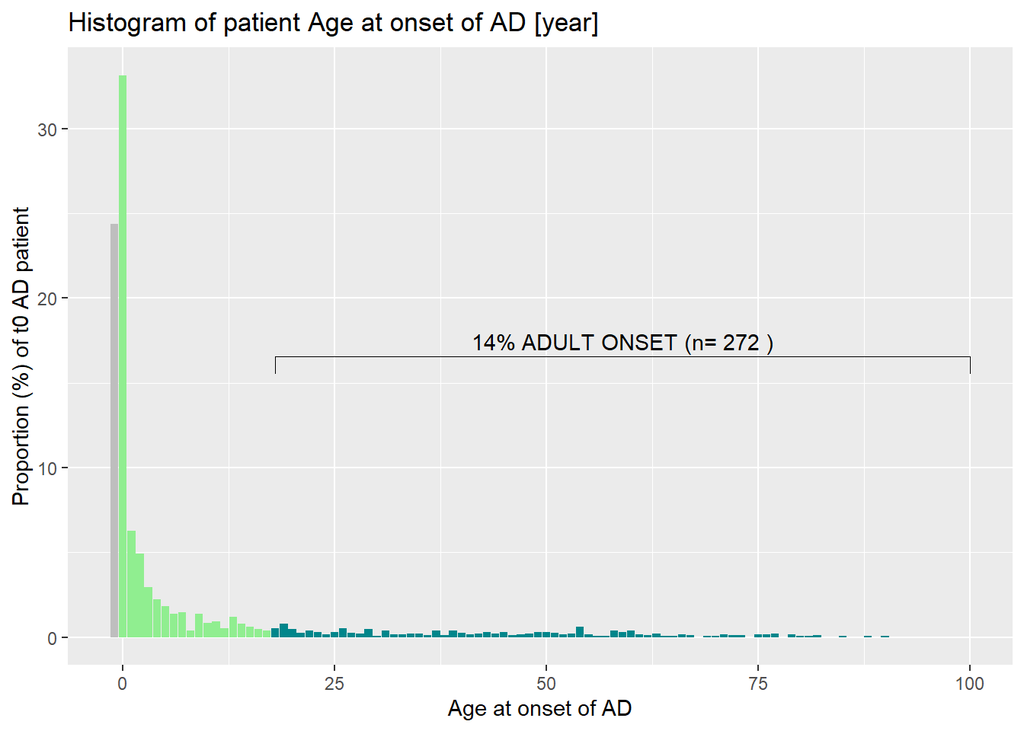

#### COMORBIDITIES

> note: As intersections will be used throughout this report, here is an illustration to explain the differences.

> All intersections, presented in this document, are Exclusive intersections.

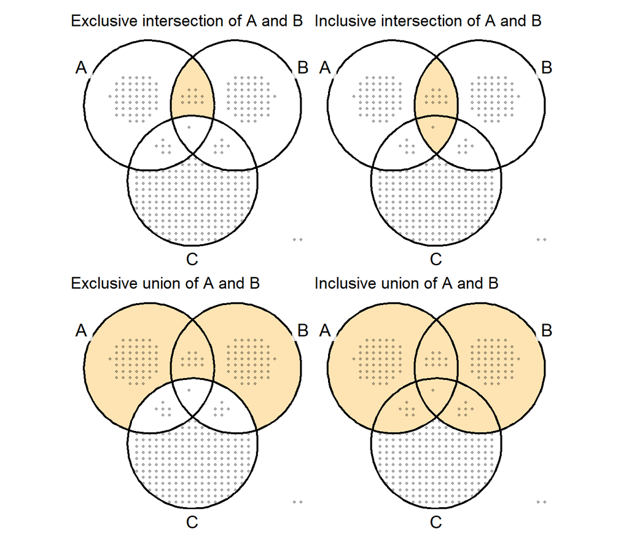

> List of the selected comorbidities at T0 on individuals with AD:

> Allergic_Rhinitis, Food_Allergy, Asthma, Psoriasis, Diabetes, Multiple_sclerosis, rheumatic, bowel_disease, cardiological, tumor, Other(manually enter answer).

> Only the first 20 intersections are represented. (combinaisons of comorbidities with the most individuals)

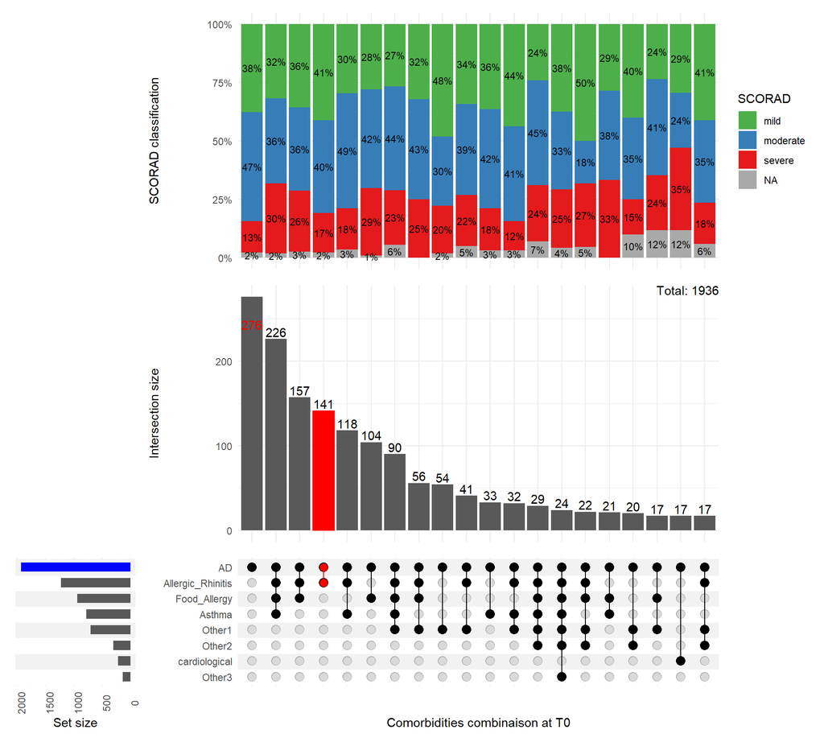

#### GENDER

> Distribution of gender within AD population and within non-AD population (individuals with no AD)

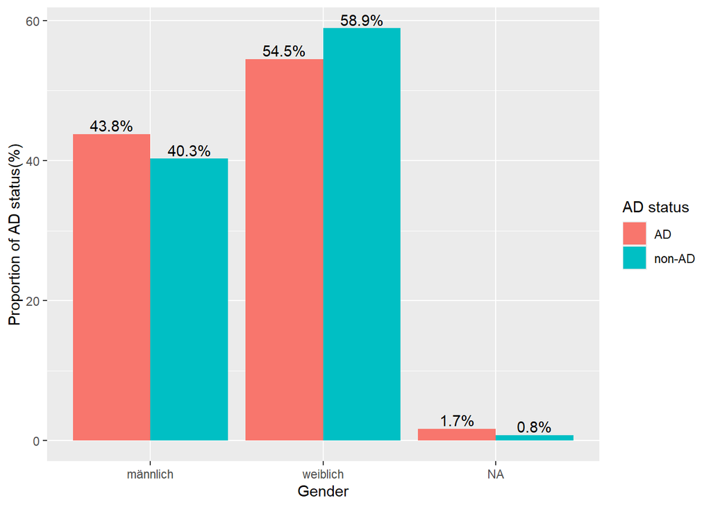

#### FAMILY HISTORY

> Look for allergic disease or AD in the family history.

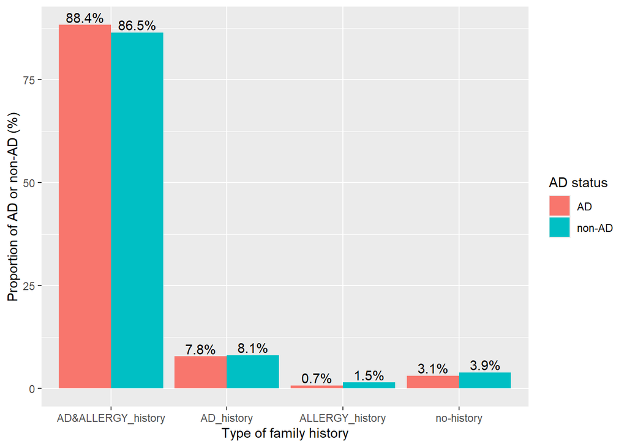

#### THERAPY TYPE

> - The medication used by the patients can be divided in 3 types:
>   - systemisch
>   - lokal
>   - inhalativ

> Look at the number of treatment type betweend AD and non-AD patient

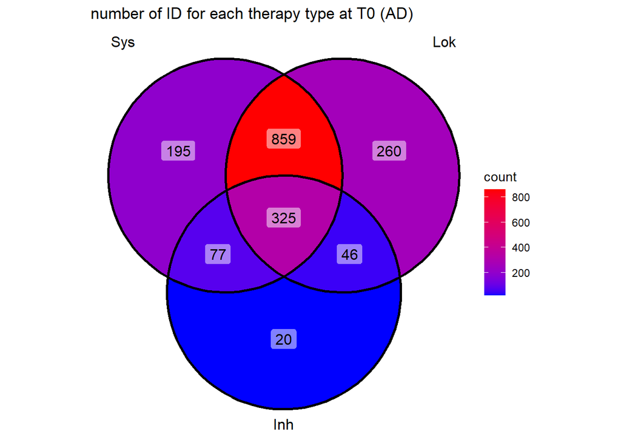

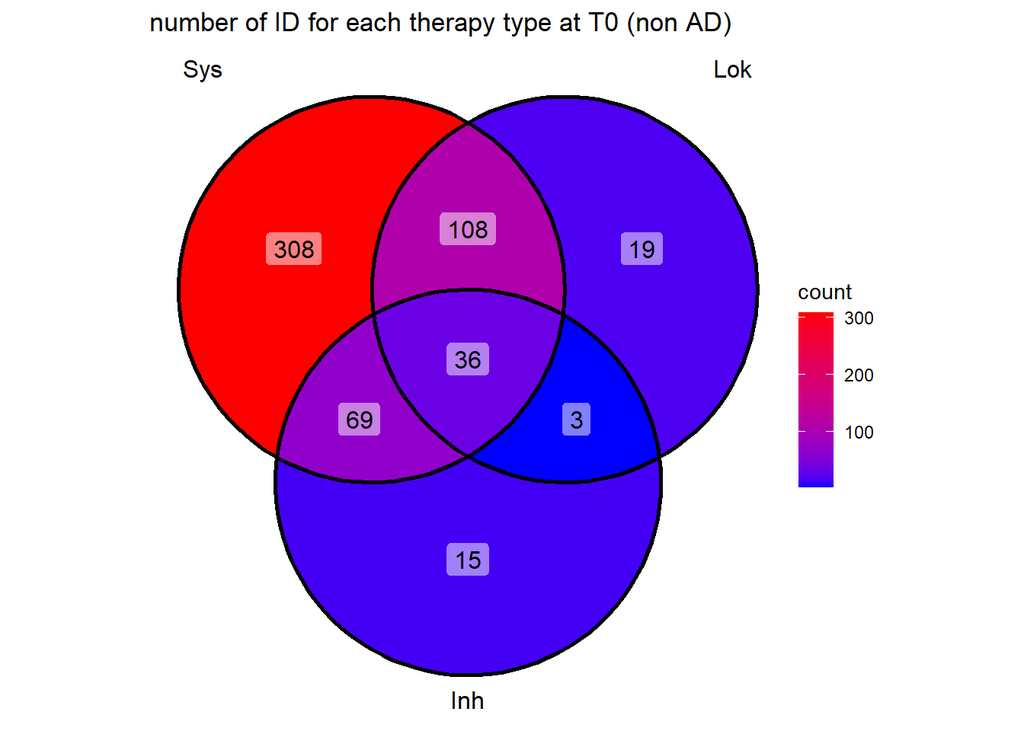

#### THERAPY DETAIL

> One of the medication of interest is the Dupilumab (dupixent)

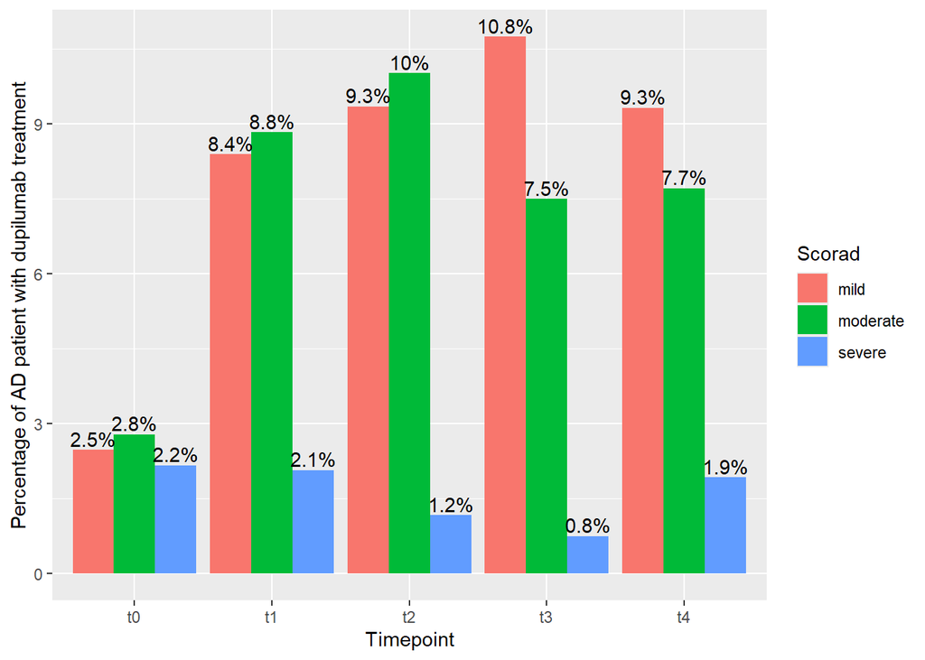

> Table of number of ID with **dupilumab, dupixent** medication (ATC: **d11ah05**)

| visit | AD_severity_scorad | Nb_ID |
| --- | --- | --- |
| t0 | mild | 48 |
| t0 | moderate | 54 |
| t0 | severe | 42 |
| t1 | mild | 77 |
| t1 | moderate | 81 |
| t1 | severe | 19 |
| t2 | mild | 56 |
| t2 | moderate | 60 |
| t2 | severe | 7 |
| t3 | mild | 43 |
| t3 | moderate | 30 |
| t3 | severe | 3 |
| t4 | mild | 29 |
| t4 | moderate | 24 |
| t4 | severe | 6 |

## PRORAD OPENSPECIMEN

> **2738** ID in PRORAD openspecimen **90337** samples in PRORAD openspecimen

> Total number of samples in PRORAD openspecimen

| Specimen_Type | Total |
| --- | --- |
| skin_swab | 14926 |
| skin_biopsy | 978 |
| whole_blood | 8732 |
| edta_aliquot | 15727 |
| pbmc_aliquot | 23333 |
| serum_aliquot | 26641 |

### PRORAD SAMPLE INCLUSION

> Look at the number of sample for each center

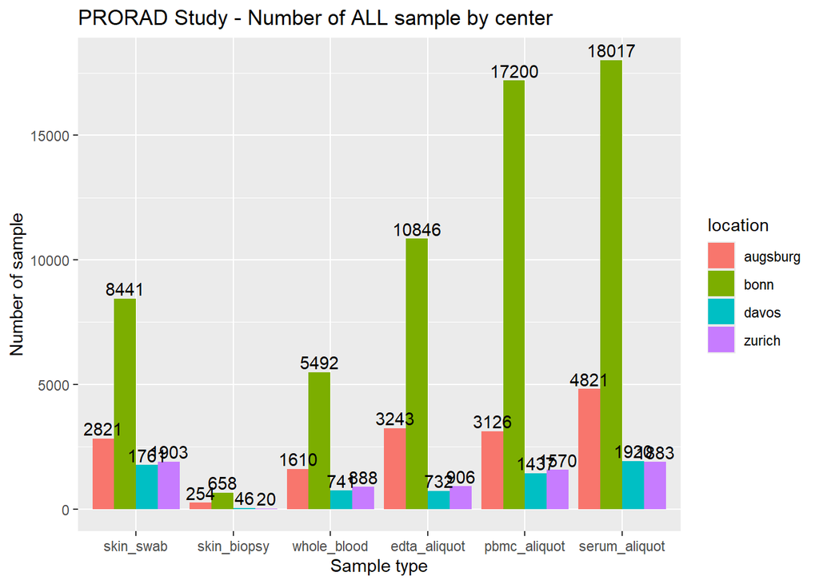

### PRORAD SAMPLE COUNT PER YEAR FOR EACH CENTER

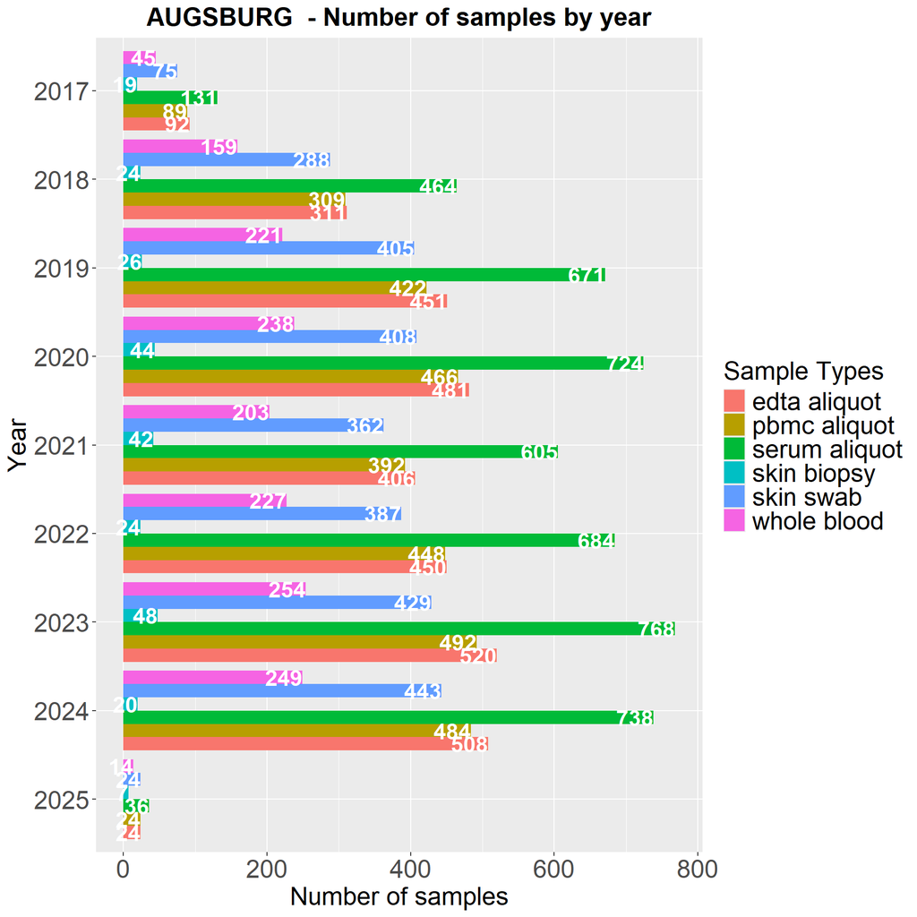

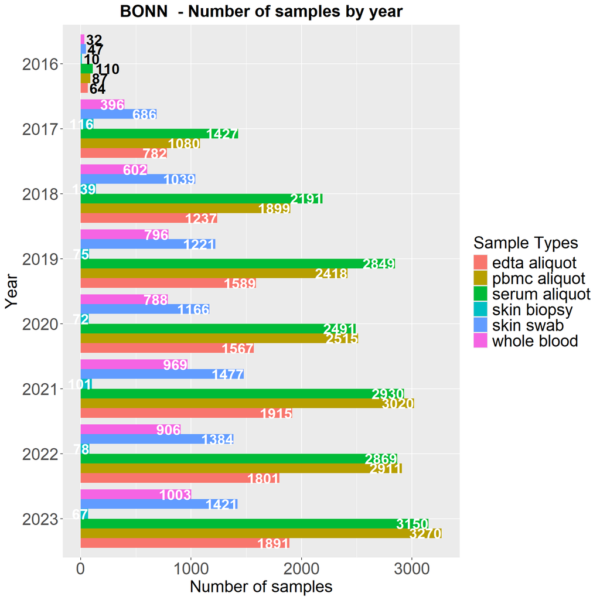

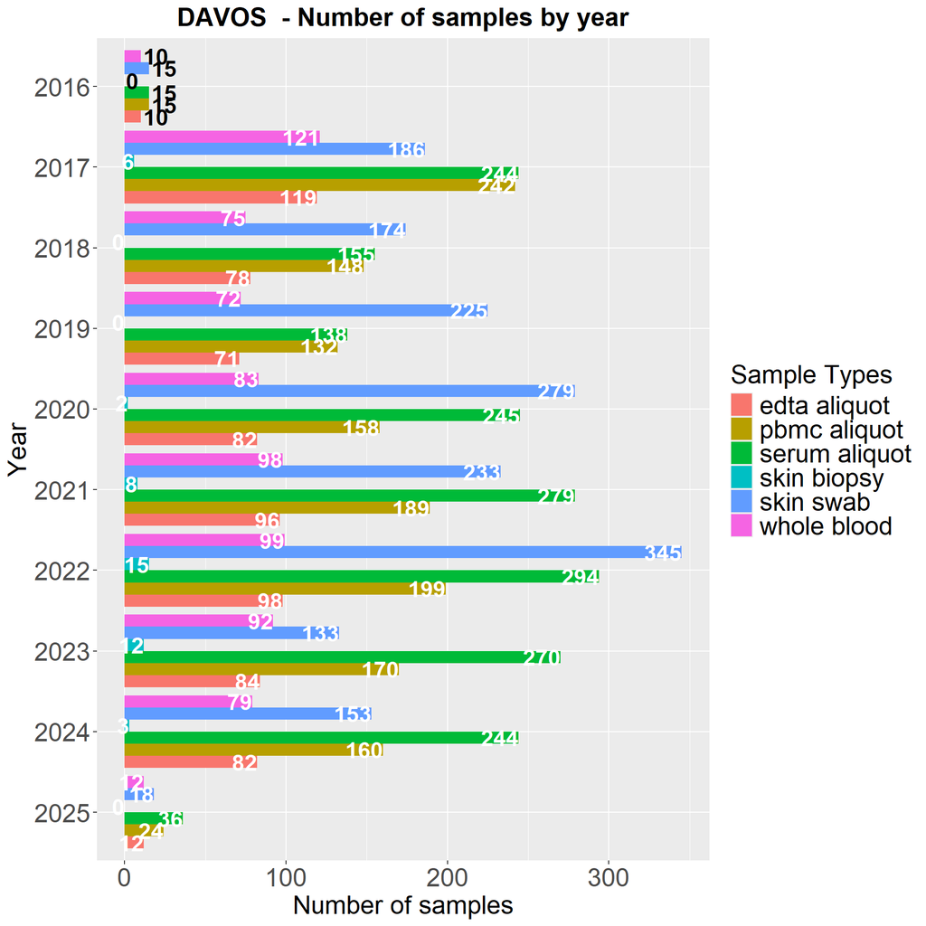

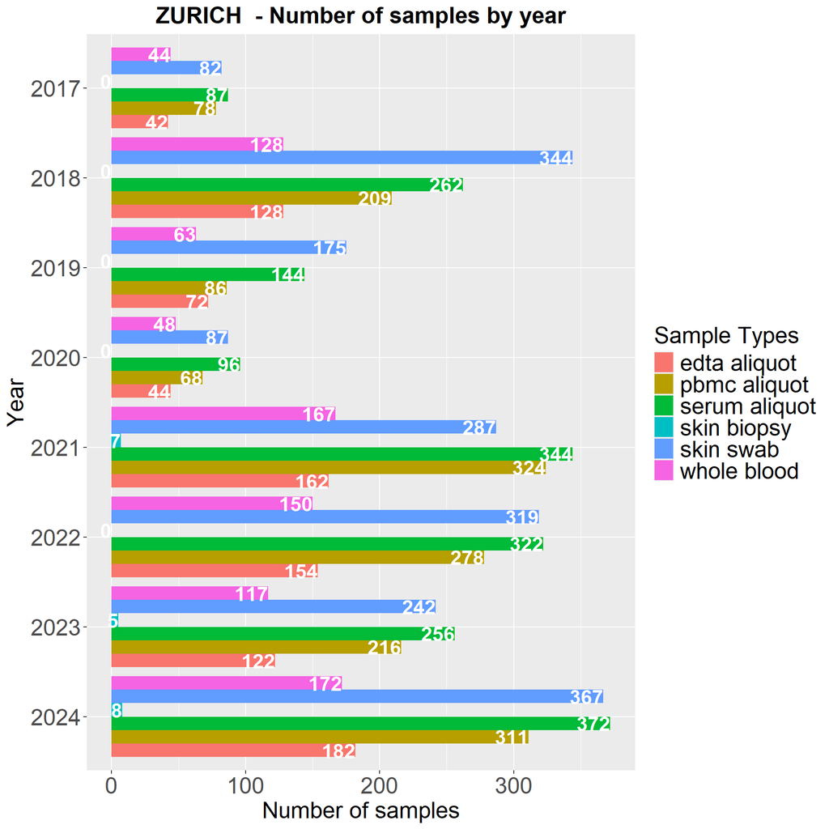

### PRORAD BIOBANK STATUS

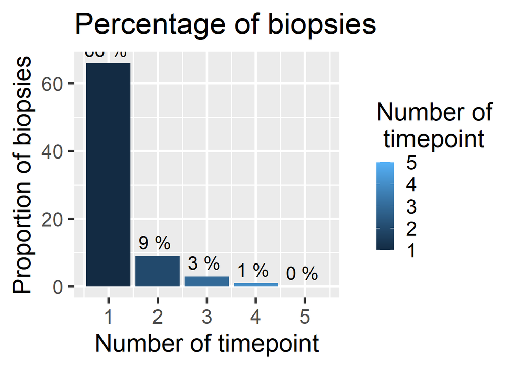

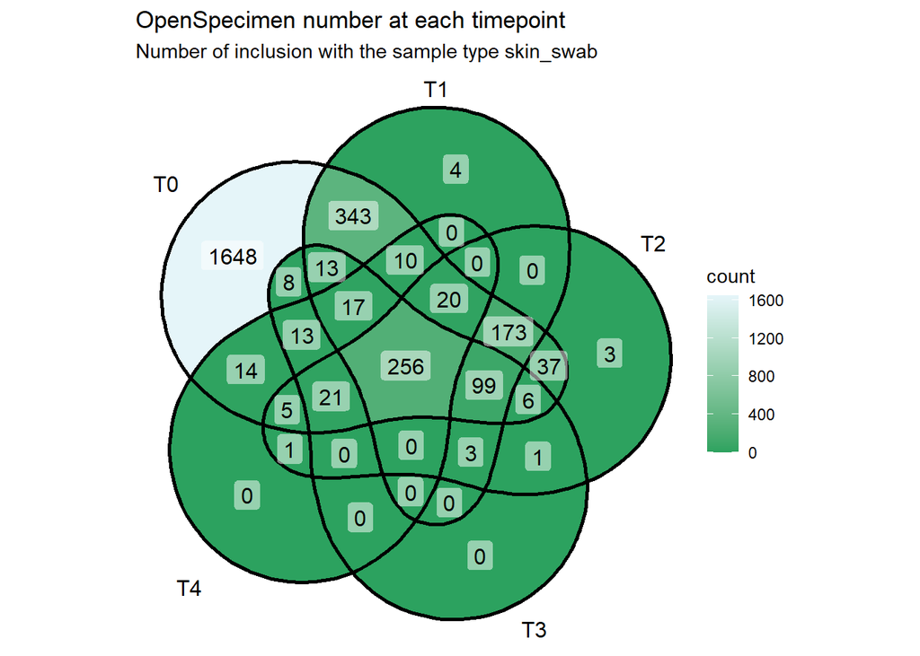

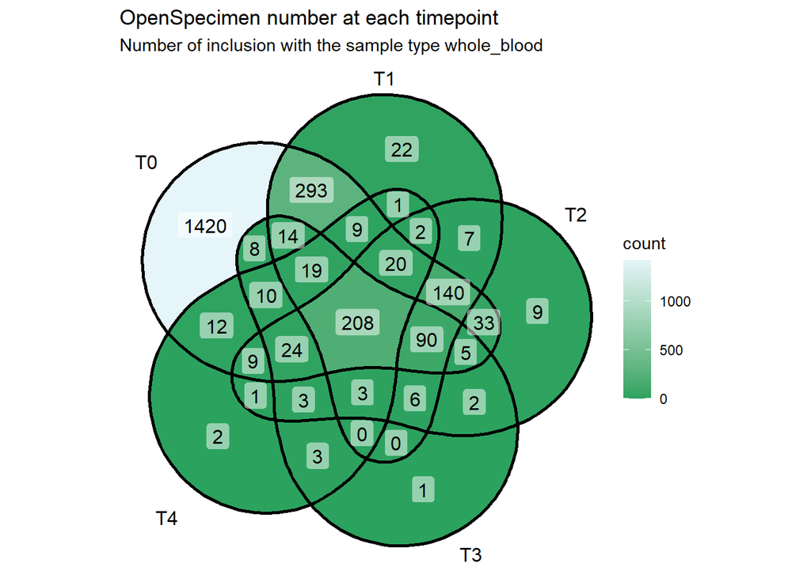

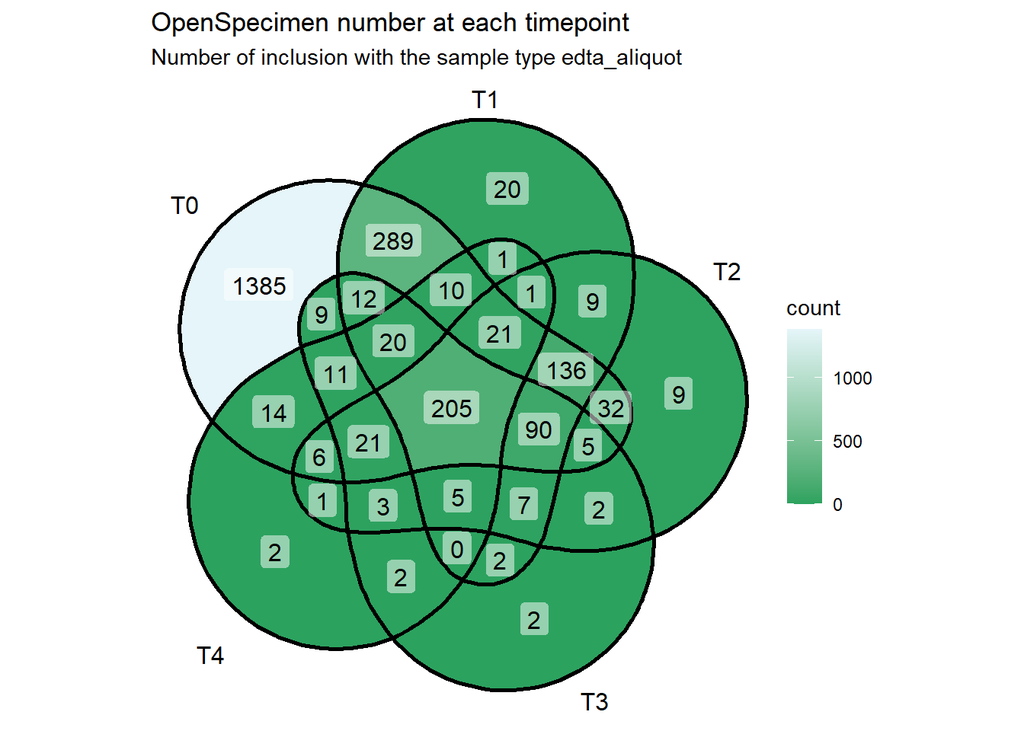

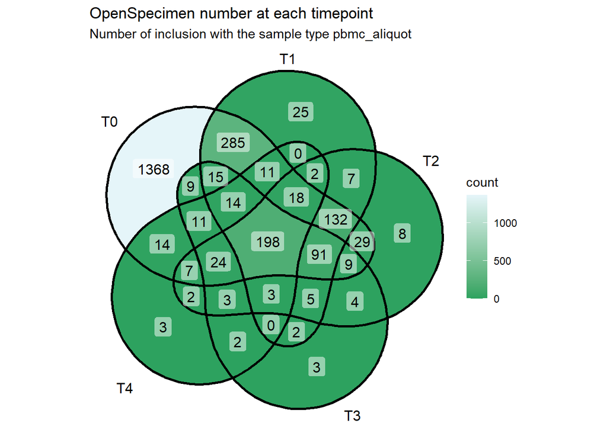

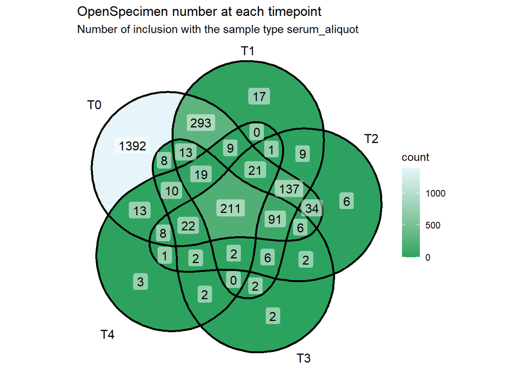

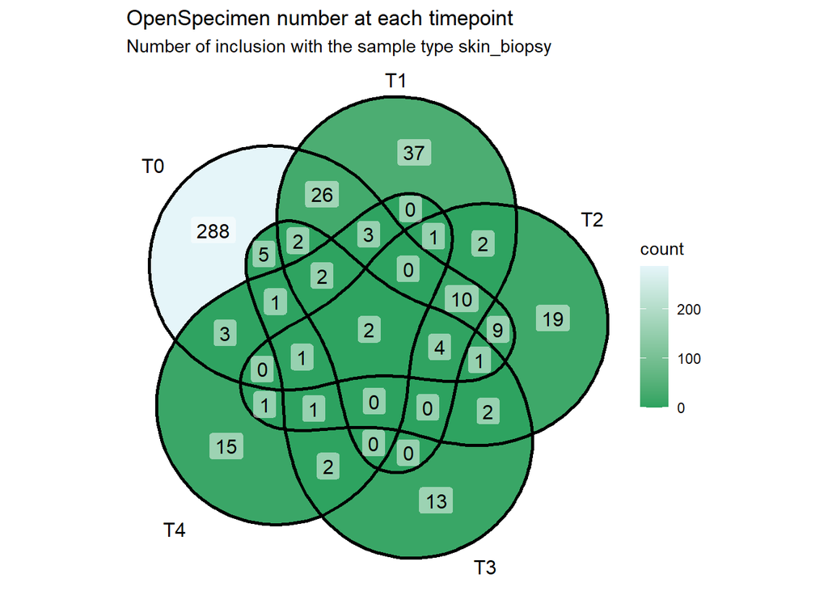

> Note: Very few individuals have a skin biopsy

> Number of inclusion with the sample type at all timepoints:

| Sample Type | Number ID | With AD | Without AD | NA |
| --- | --- | --- | --- | --- |
| skin_swab | 259 | 247 | 12 | 0 |
| whole_blood | 210 | 201 | 9 | 0 |
| edta_aliquot | 207 | 198 | 9 | 0 |
| pbmc_aliquot | 199 | 191 | 8 | 0 |
| serum_aliquot | 213 | 204 | 9 | 0 |
| skin_biopsy | 2 | 2 | 0 | 0 |

## NIA APP DATA

> **74** ID in the NIA database

> Most of the completion done within 10 minutes

> 3 patient with a completion time greater than 60 min

> (95min, 33067min (22days) and 51069min (35days) )

> Example of information available in the database:
> - Stress, outdoorsHours, AD flares
> - Local and systemic therapies
> - Food avoidance and reasons
> - SCORES DLQI and PO-SCORE are available in details

Number of time the patient used the app

| Number_use | Number_patient |
| --- | --- |
| 1 | 14 |
| 2 | 14 |
| 3 | 10 |
| 4 | 10 |
| 5 | 6 |
| 6 | 3 |
| 7 | 2 |
| 8 | 2 |
| 9 | 3 |
| 10 | 2 |
| 11 | 2 |
| 13 | 1 |
| 14 | 2 |
| 16 | 1 |
| 17 | 1 |
| 18 | 1 |